# Nanostring Analysis

W. Evan Johnson, Ph.D. Professor, Division of Infectious Disease Director, Center for Data Science Rutgers University – New Jersey Medical School

10/2/2023

# Read in the data

```r
# Read in the data
nano_data <- readRDS("nano_tibble.rds")
datatable(nano_data)
```

|  | TBStatus | AGAP9 | AIRE | ANKRD22 | APOL1 | APOL6 | ATP1A1 | BATF2 | BCL6 | BLK | C16orf7 | C1QB | C1QC | C4ORF18 | C5 | CCDC14 | CCDC78 | CCR6 | CD1C | CD79A | CD79B | CIRBP | CTSA | CXCR5 | CXorf40B | CYP4F3 | DARS2 | DERA | DUSP3 | … |
| --- | --- | --- | --- | --- | --- | --- | --- | --- | --- | --- | --- | --- | --- | --- | --- | --- | --- | --- | --- | --- | --- | --- | --- | --- | --- | --- | --- | --- | --- | --- |
| 1 | TB | 13.06040617009138 | 6.605846332824179 | 9.11276037002494 | 12.64683809039871 | 13.14003431941859 | 10.3120030421538 | 12.08388728518598 | 15.24024355066955 | 9.82224462805409 | 8.732371973186453 | 8.855892892772962 | 7.029740508185441 | 11.70908000183822 | 8.042924403766339 | 9.566002950945911 | 6.533679126459417 | 8.91390131042396 | 10.15248676372758 | 12.71877951516091 | 11.39200489038443 | 13.45167309038556 | 12.96502063952091 | 9.547797801263178 | 10.63447557476067 | 14.4847962621668 | 9.814651285866704 | 9.670658157684493 | 11.90594381566956 | … |
| 2 | TB | 12.94111728569068 | 6.052330040373022 | 9.121325161001929 | 12.0941936133215 | 12.61572927574257 | 10.3623517170195 | 11.14051794489784 | 14.69360792874114 | 8.275309445784917 | 8.56554417314642 | 9.528662714613256 | 8.22363347900497 | 12.58448925363172 | 8.592956174892349 | 9.102374880974597 | 6.338050477042396 | 8.30875959677764 | 10.25918838734119 | 10.67928253767673 | 9.986939013054169 | 13.09103486716018 | 13.88772565207835 | 7.774664004447436 | 10.58686847996377 | 14.24063586091777 | 9.418064730970066 | 10.39775577219347 | 12.25941315592562 | … |
| 3 | TB | 12.87738156088746 | 6.96874024237053 | 8.034961554546193 | 12.32312233136061 | 13.29456685076618 | 11.1091474697559 | 11.35015099350523 | 14.51831176815878 | 8.817869593409439 | 7.779752981224235 | 8.00873460918825 | 6.598525302341023 | 12.93248315285969 | 8.817869593409439 | 9.464389852470642 | 5.996212295019727 | 8.740294695843865 | 8.905768076481372 | 11.67181291378254 | 10.13213742103619 | 13.33470916478942 | 13.90896286667014 | 8.359436300788037 | 10.65607765698316 | 13.72083782149633 | 9.502480600110852 | 10.10763346042762 | 12.07714973683953 | … |
| 4 | TB | 12.70864171651869 | 6.419473808546916 | 9.556030418367548 | 12.9247091268659 | 13.36535423673795 | 10.26066487334431 | 12.20259817405555 | 15.47529041313223 | 8.545066677711768 | 8.995679389602309 | 8.860532850353017 | 6.95676457074959 | 12.77157463743577 | 7.797911876838599 | 9.025147822542761 | 6.58691745584407 | 8.611331747931656 | 8.849593097859392 | 11.54737185386724 | 10.14462906186507 | 13.25671640477515 | 13.64070672178763 | 8.22779986144115 | 10.45363147737762 | 13.92491205246338 | 8.903480717107954 | 10.09454262960256 | 12.65073707534586 | … |
| 5 | TB | 13.71916056763351 | 6.662025441883602 | 6.528671525826699 | 10.79579216257428 | 11.89962188529483 | 11.15096430617136 | 9.014080276025913 | 14.55265193412292 | 10.46718438094181 | 7.316358663205753 | 6.457067904828492 | 5.821777080281672 | 13.15170335309611 | 8.457848286936574 | 10.34357922450563 | 6.528671525826699 | 10.37791291976079 | 11.05115560991845 | 13.55898576577212 | 12.21252366212306 | 13.77313618607079 | 13.36784023617521 | 9.997440585007485 | 11.10485430753196 | 13.63497154726531 | 10.18641159780116 | 10.67869729450265 | 11.90299403863131 | … |
| 6 | TB | 12.28788823659687 | 6.665607754843731 | 8.716693123470309 | 12.6412763230775 | 12.92955926811179 | 10.03389354320726 | 12.17157493410532 | 15.06750867098114 | 8.46176841008262 | 8.222910140418874 | 9.262990832577136 | 7.27906147084378 | 12.27958676219242 | 8.51930761781067 | 9.336862429060098 | 5.778610198307858 | 8.823339227123935 | 8.561004377596921 | 10.91483992723954 | 9.763244536317293 | 12.75717050203871 | 13.74504697332192 | 7.55146926958028 | 9.947450244390538 | 13.51024736901787 | 8.765067105130608 | 10.17036188791691 | 12.19604105405104 | … |
| 7 | TB | 13.2761854072282 | 6.175443581132293 | 9.093616483387144 | 12.10452863952367 | 12.92257688244726 | 10.6944345805915 | 11.12501523063222 | 14.91377277023937 | 9.068859508063673 | 7.932126328386844 | 7.149636223426684 | 6.265352199605644 | 12.43751321741431 | 8.251023556547096 | 9.62204734454154 | 6.646179922732692 | 8.764156006815892 | 9.506961079379447 | 12.13018255432429 | 10.96985689249415 | 14.13329988655172 | 13.35060661268127 | 8.86825799416782 | 11.04793832798827 | 15.07824360066656 | 9.790504826943788 | 10.10856428277459 | 11.5752324165915 | … |
| 8 | TB | 12.26447204255057 | 6.569521366502705 | 9.428960542159048 | 12.15829282332782 | 13.44044156905345 | 9.855147388592378 | 12.37808698436445 | 14.47880021581959 | 8.337881862232996 | 8.201958520553978 | 9.162186437545078 | 7.178416465668493 | 13.19784917104246 | 8.512220375552202 | 9.253428388391452 | 6.366496664697546 | 7.934246336416235 | 9.064782040885088 | 10.68765917224098 | 9.339241466694977 | 12.9044878724412 | 13.1843860329767 | 7.371820954468894 | 10.86529741738221 | 13.89670420791148 | 9.233645240342275 | 9.72658431061284 | 11.90045738860231 | … |
| 9 | TB | 12.50588739829982 | 7.000448357032327 | 10.58947487391717 | 13.03939553356203 | 13.56154196169579 | 10.19109579078723 | 13.50614582943646 | 14.7617243252132 | 8.13647799448453 | 8.474745559240263 | 10.80341866583914 | 9.199967041817622 | 12.5298937824075 | 9.081210081273976 | 9.460050420944421 | 6.429855287203144 | 8.511953700345334 | 7.40824711150244 | 11.10984337718685 | 9.460050420944421 | 12.91383218583721 | 13.99509972867543 | 7.725814461261217 | 10.15038032471512 | 13.64451078303129 | 9.199967041817622 | 9.961566061923863 | 12.74927850342037 | … |
| 10 | TB | 12.52366208228806 | 6.958819352277473 | 9.72054535434133 | 12.77899882531177 | 13.5347543758878 | 10.11997044944253 | 12.70163357757181 | 14.99969304405129 | 8.449058661654574 | 8.254748828691119 | 9.444775999010293 | 8.08315714901377 | 12.35604647984344 | 8.954980402066331 | 9.284220055177128 | 6.237783729048786 | 8.428716734274461 | 8.740681283452577 | 11.44914980801559 | 9.703713214900965 | 12.65423684666326 | 13.62636020119983 | 7.796097711416038 | 10.20615525716534 | 14.03448378833635 | 9.024405249367883 | 9.817611486537162 | 12.21171658363457 | … |

[output cut: 169 more lines]

# Logistic Regression LASSO, Ridge, and Elastic Net

## LASSO

Set family option to “binomial” in the glmnet function:

```r
fit <- glmnet(nano_data[,-1],nano_data$TBStatus, family = "binomial")
```

### Visualize L1

We can visualize the coefficients by executing the plot method:

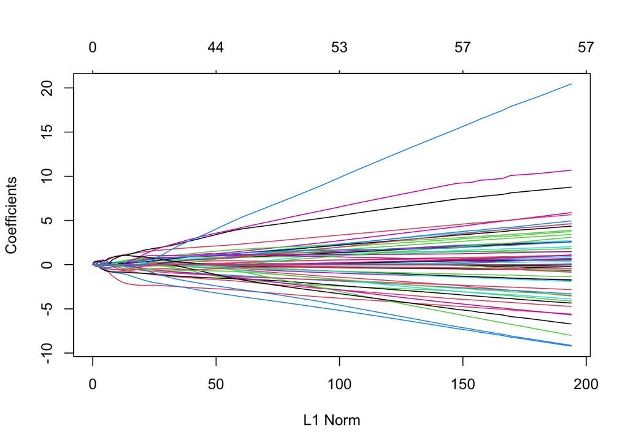

```r
plot(fit)
```

### Print summary

A summary of the glmnet path at each step is displayed if we just enter the object name or use the print function:

```r
print(fit)
```

```
##
## Call:  glmnet(x = nano_data[, -1], y = nano_data$TBStatus, family = "binomial")
##
##     Df  %Dev  Lambda
## 1    0  0.00 0.36070
## 2    1  6.52 0.32870
## 3    3 12.64 0.29950
## 4    4 18.18 0.27290
## 5    4 22.99 0.24860
## 6    4 27.18 0.22650
## 7    6 31.02 0.20640
## 8    7 34.44 0.18810
## 9    7 37.48 0.17140
## 10   7 40.19 0.15620
## 11   8 42.61 0.14230
```

[output cut: 89 more lines]

### Results $\lambda=0.3$

Model coefficients for $\lambda = 0.3$:

```r
coef(fit, s = .3)
```

```
## 108 x 1 sparse Matrix of class "dgCMatrix"
##                      s1
## (Intercept) -2.83992237
## AGAP9        .
## AIRE         .
## ANKRD22      .
## APOL1        .
## APOL6        .
## ATP1A1       .
## BATF2        .
## BCL6         .
## BLK          .
## C16orf7      .
## C1QB         .
## C1QC         .
## C4ORF18      .
## C5           .
## CCDC14       .
## CCDC78       .
## CCR6         0.04705478
## CD1C         .
## CD79A        .
## CD79B        .
## CIRBP        .
## CTSA         .
## CXCR5        .
## CXorf40B     .
## CYP4F3       .
## DARS2        .
## DERA         .
## DUSP3        .
## ENO3         .
## ETV7         .
## EXOC2        .
## FAM20A       .
## FCER1G       .
## FCGR1A       .
## FCGR1B       .
## FLVCR2       .
## FUT4         .
```

[output cut: 55 more lines]

```
## UCP2         .
## VAMP5        .
## WARS         .
## ZNF202       .
## ZNF296       .
## ZNF419       .
## ZNRF1        .
## ACTB         .
## FCGR1C       .
## GAPDH        .
## GUSB         .
## HPRT1        .
## LOC728744    .
## PGK1         .
## TBP          .
```

### Results $\lambda = 0.2$:

```r
coef(fit, s = .2)
```

```
## 108 x 1 sparse Matrix of class "dgCMatrix"
##                       s1
## (Intercept) -6.277492713
## AGAP9        .
## AIRE         .
## ANKRD22      .
## APOL1        .
## APOL6        .
## ATP1A1       .
## BATF2       -0.015946303
## BCL6         .
## BLK          .
## C16orf7      .
## C1QB         .
## C1QC         .
## C4ORF18      .
## C5           .
## CCDC14       .
## CCDC78       .
## CCR6         0.216913925
## CD1C         .
## CD79A        .
## CD79B        .
## CIRBP        .
## CTSA         .
## CXCR5        .
## CXorf40B     .
## CYP4F3       .
## DARS2        .
## DERA         .
## DUSP3        .
## ENO3         .
## ETV7         .
## EXOC2        0.008625008
## FAM20A      -0.035952690
## FCER1G       .
## FCGR1A       .
## FCGR1B       .
## FLVCR2       .
## FUT4         .
```

[output cut: 55 more lines]

```
## UCP2         .
## VAMP5        .
## WARS         .
## ZNF202       .
## ZNF296       .
## ZNF419       .
## ZNRF1        .
## ACTB         .
## FCGR1C       .
## GAPDH        .
## GUSB         .
## HPRT1        .
## LOC728744    .
## PGK1         .
## TBP          .
```

### Results $\lambda=0.1$

Model coefficients for $\lambda = 0.1$:

```r
coef(fit, s = 0.1)
```

```
## 108 x 1 sparse Matrix of class "dgCMatrix"
##                       s1
## (Intercept) -6.966411794
## AGAP9        .
## AIRE         .
## ANKRD22      .
## APOL1        .
## APOL6        .
## ATP1A1       .
## BATF2       -0.010645177
## BCL6         .
## BLK          .
## C16orf7      .
## C1QB         .
## C1QC         .
## C4ORF18      .
## C5           .
## CCDC14       .
## CCDC78       .
## CCR6         0.318487840
## CD1C         .
## CD79A        .
## CD79B        .
## CIRBP        .
## CTSA         .
## CXCR5        .
## CXorf40B     .
## CYP4F3       .
## DARS2        .
## DERA         .
## DUSP3       -0.041668526
## ENO3         .
## ETV7         .
## EXOC2        0.301933163
## FAM20A      -0.192945860
## FCER1G       .
## FCGR1A       .
## FCGR1B       .
## FLVCR2       .
## FUT4         .
```

[output cut: 55 more lines]

```
## UCP2         .
## VAMP5        .
## WARS         .
## ZNF202       .
## ZNF296       0.021271488
## ZNF419       0.069123598
## ZNRF1        .
## ACTB         .
## FCGR1C       .
## GAPDH        .
## GUSB         .
## HPRT1        .
## LOC728744    .
## PGK1         .
## TBP          .
```

### Results $\lambda=0.05$

Model coefficients for $\lambda = 0.05$:

```r
coef(fit, s = 0.05)
```

```
## 108 x 1 sparse Matrix of class "dgCMatrix"
##                      s1
## (Intercept) 10.86631609
## AGAP9        .
## AIRE         0.04416994
## ANKRD22      .
## APOL1        .
## APOL6        .
## ATP1A1       0.11737690
## BATF2       -0.02253229
## BCL6         .
## BLK          .
## C16orf7      .
## C1QB         .
## C1QC         .
## C4ORF18     -0.27558398
## C5           .
## CCDC14       .
## CCDC78       .
## CCR6         0.28178160
## CD1C         .
## CD79A        .
## CD79B        .
## CIRBP        .
## CTSA        -0.38604175
## CXCR5        .
## CXorf40B     .
## CYP4F3      -0.30295478
## DARS2        .
## DERA         .
## DUSP3        .
## ENO3         .
## ETV7         .
## EXOC2        0.03453142
## FAM20A      -0.32519746
## FCER1G       .
## FCGR1A       .
## FCGR1B       .
## FLVCR2       .
## FUT4         .
```

[output cut: 55 more lines]

```
## UCP2         .
## VAMP5        .
## WARS         .
## ZNF202       .
## ZNF296       0.10461517
## ZNF419       .
## ZNRF1        .
## ACTB         .
## FCGR1C       .
## GAPDH        .
## GUSB         .
## HPRT1        .
## LOC728744    .
## PGK1         .
## TBP          .
```

### Cross-validation

The function **glmnet** returns a sequence of models for the users to choose from. **Cross-validation** is perhaps the simplest and most widely used method to select a model. **cv.glmnet** is the main function to do cross-validation here, along with various supporting methods such as plotting and prediction.

```r
set.seed(0)
cvfit <- cv.glmnet(as.matrix(nano_data[,-1]), nano_data$TBStatus, family = "binomial",
                   type.measure = "class")
```

#### Cross-validation plot

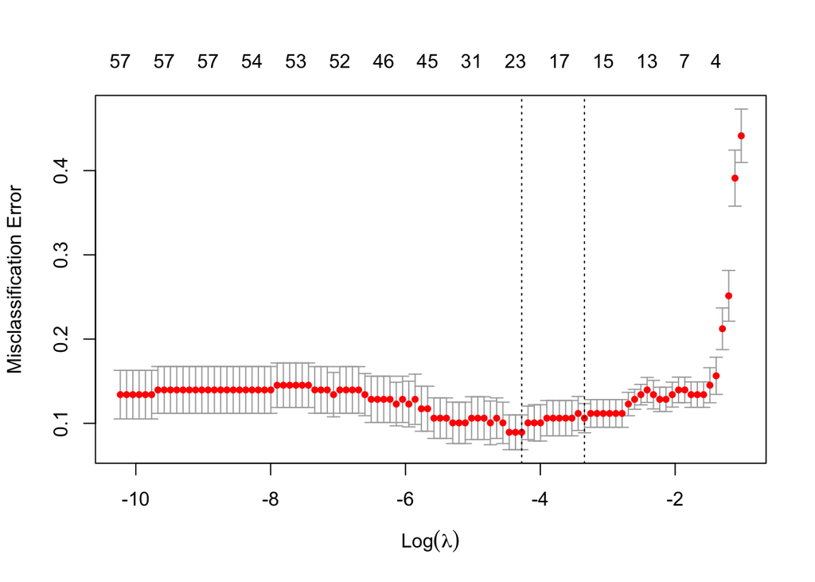

```r
plot(cvfit)
```

#### $\lambda_{min}$ value

We can get the value of $\lambda_{min}$ and the model coefficients:

```r
cvfit$lambda.min
```

```
## [1] 0.01390075
```

#### Coefficients at $\lambda_{min}$

```r
coef(cvfit, s = "lambda.min")
```

```
## 108 x 1 sparse Matrix of class "dgCMatrix"
##                      s1
## (Intercept) 25.41100789
## AGAP9        .
## AIRE         0.16134117
## ANKRD22      .
## APOL1        .
## APOL6        .
## ATP1A1       .
## BATF2        .
## BCL6         .
## BLK          .
## C16orf7      .
## C1QB        -0.05723817
## C1QC         .
## C4ORF18     -0.55640392
## C5           .
## CCDC14       .
## CCDC78       .
## CCR6         0.32494881
## CD1C         .
## CD79A        .
## CD79B        .
## CIRBP        .
## CTSA        -1.78337529
## CXCR5        .
## CXorf40B     .
## CYP4F3      -0.96227842
## DARS2        .
## DERA         .
## DUSP3        .
## ENO3         .
## ETV7         .
## EXOC2        .
## FAM20A      -0.59669645
## FCER1G       0.22742174
## FCGR1A       .
## FCGR1B       .
## FLVCR2       .
## FUT4         .
```

[output cut: 55 more lines]

```
## UCP2         .
## VAMP5        .
## WARS         .
## ZNF202       .
## ZNF296       0.25993965
## ZNF419       .
## ZNRF1        .
## ACTB         0.90225708
## FCGR1C       .
## GAPDH        .
## GUSB         .
## HPRT1        .
## LOC728744   -0.13542050
## PGK1         .
## TBP          .
```

## Ridge Regression

Set family option to “binomial” in the glmnet function:

```r
fit <- glmnet(nano_data[,-1],nano_data$TBStatus, family = "binomial", alpha=0)
```

### Visualize L2

We can visualize the coefficients by executing the plot method:

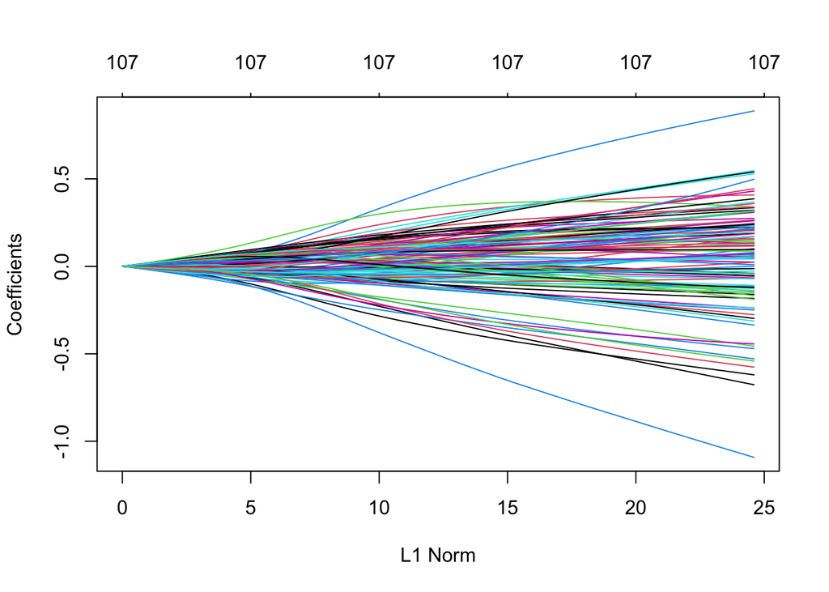

```r
plot(fit)
```

### Print summary

A summary of the glmnet path at each step is displayed if we just enter the object name or use the print function:

```r
print(fit)
```

```
##
## Call:  glmnet(x = nano_data[, -1], y = nano_data$TBStatus, family = "binomial",      alpha = 0)
##
##      Df  %Dev Lambda
## 1   107  0.00 360.70
## 2   107  3.05 328.70
## 3   107  3.33 299.50
## 4   107  3.64 272.90
## 5   107  3.97 248.60
## 6   107  4.33 226.50
## 7   107  4.71 206.40
## 8   107  5.13 188.10
## 9   107  5.59 171.40
## 10  107  6.07 156.20
## 11  107  6.60 142.30
```

[output cut: 89 more lines]

### Results $\lambda=0.3$

Model coefficients for $\lambda = 0.3$:

```r
coef(fit, s = .3)
```

```
## 108 x 1 sparse Matrix of class "dgCMatrix"
##                        s1
## (Intercept) -1.414671e+01
## AGAP9        1.433806e-02
## AIRE         2.097707e-01
## ANKRD22     -5.109599e-02
## APOL1       -3.007061e-03
## APOL6       -9.994100e-02
## ATP1A1       1.548488e-01
## BATF2       -6.399544e-02
## BCL6         9.738444e-04
## BLK          7.306093e-02
## C16orf7     -9.602637e-02
## C1QB        -4.105558e-02
## C1QC        -1.286326e-02
## C4ORF18     -2.508199e-01
## C5          -5.830279e-02
## CCDC14       3.801017e-02
## CCDC78      -4.830089e-02
## CCR6         1.065504e-01
## CD1C         1.473157e-02
## CD79A        3.261113e-02
## CD79B        3.180316e-02
## CIRBP        3.182965e-02
## CTSA        -3.220579e-01
## CXCR5        4.009946e-02
## CXorf40B     1.212824e-01
## CYP4F3      -1.941663e-01
## DARS2        1.232376e-01
## DERA         6.873145e-02
## DUSP3       -2.248685e-01
## ENO3         1.833552e-01
## ETV7        -1.318320e-02
## EXOC2        1.478318e-01
## FAM20A      -8.440183e-02
## FCER1G       6.724465e-02
## FCGR1A      -2.141004e-02
## FCGR1B      -2.821310e-02
## FLVCR2      -4.380812e-02
## FUT4         5.999560e-02
```

[output cut: 55 more lines]

```
## UCP2         6.684663e-02
## VAMP5       -4.749000e-02
## WARS         5.355070e-02
## ZNF202       7.841255e-02
## ZNF296       1.453947e-01
## ZNF419       1.102627e-01
## ZNRF1        9.708726e-02
## ACTB         7.610030e-02
## FCGR1C      -2.881408e-02
## GAPDH       -1.946922e-01
## GUSB         2.270930e-02
## HPRT1        9.034397e-02
## LOC728744   -1.551907e-01
## PGK1         6.156233e-02
## TBP          1.043849e-01
```

### Results $\lambda = 0.2$:

```r
coef(fit, s = .2)
```

```
## 108 x 1 sparse Matrix of class "dgCMatrix"
##                        s1
## (Intercept) -1.739569e+01
## AGAP9        3.905964e-03
## AIRE         2.560607e-01
## ANKRD22     -5.734131e-02
## APOL1        2.208711e-02
## APOL6       -1.126970e-01
## ATP1A1       1.772348e-01
## BATF2       -7.556195e-02
## BCL6         1.910237e-02
## BLK          8.336138e-02
## C16orf7     -1.152030e-01
## C1QB        -4.770462e-02
## C1QC        -6.352604e-03
## C4ORF18     -3.057358e-01
## C5          -4.851131e-02
## CCDC14       2.816935e-02
## CCDC78      -7.789188e-02
## CCR6         1.271884e-01
## CD1C         7.723589e-03
## CD79A        2.780559e-02
## CD79B        2.593647e-02
## CIRBP        1.775355e-02
## CTSA        -4.173880e-01
## CXCR5        4.005420e-02
## CXorf40B     1.342155e-01
## CYP4F3      -2.518198e-01
## DARS2        1.387186e-01
## DERA         6.985627e-02
## DUSP3       -2.631714e-01
## ENO3         2.294869e-01
## ETV7        -1.533580e-02
## EXOC2        1.674979e-01
## FAM20A      -1.040729e-01
## FCER1G       9.331672e-02
## FCGR1A      -1.444403e-02
## FCGR1B      -2.074113e-02
## FLVCR2      -3.163224e-02
## FUT4         7.892278e-02
```

[output cut: 55 more lines]

```
## UCP2         5.520328e-02
## VAMP5       -4.861905e-02
## WARS         8.517512e-02
## ZNF202       8.793735e-02
## ZNF296       1.721334e-01
## ZNF419       1.236603e-01
## ZNRF1        1.161559e-01
## ACTB         9.266453e-02
## FCGR1C      -2.190344e-02
## GAPDH       -2.377135e-01
## GUSB         1.088967e-03
## HPRT1        9.419570e-02
## LOC728744   -2.064513e-01
## PGK1         8.721510e-02
## TBP          1.141489e-01
```

### Results $\lambda=0.1$

Model coefficients for $\lambda = 0.1$:

```r
coef(fit, s = 0.1)
```

```
## 108 x 1 sparse Matrix of class "dgCMatrix"
##                        s1
## (Intercept) -2.451875e+01
## AGAP9       -1.205837e-02
## AIRE         3.357502e-01
## ANKRD22     -7.416723e-02
## APOL1        8.672782e-02
## APOL6       -1.543179e-01
## ATP1A1       2.191462e-01
## BATF2       -1.020258e-01
## BCL6         6.499575e-02
## BLK          1.055528e-01
## C16orf7     -1.594229e-01
## C1QB        -6.419303e-02
## C1QC         1.066997e-02
## C4ORF18     -4.153770e-01
## C5          -2.688016e-04
## CCDC14       3.007365e-03
## CCDC78      -1.516288e-01
## CCR6         1.768964e-01
## CD1C        -9.552207e-03
## CD79A        1.146260e-02
## CD79B        7.656500e-03
## CIRBP       -2.250653e-02
## CTSA        -6.344644e-01
## CXCR5        3.931844e-02
## CXorf40B     1.523268e-01
## CYP4F3      -3.835549e-01
## DARS2        1.735400e-01
## DERA         7.741448e-02
## DUSP3       -3.442197e-01
## ENO3         3.290284e-01
## ETV7        -2.627471e-02
## EXOC2        1.995015e-01
## FAM20A      -1.519203e-01
## FCER1G       1.498406e-01
## FCGR1A       5.786009e-03
## FCGR1B       2.240326e-03
## FLVCR2       3.340411e-03
## FUT4         1.184000e-01
```

[output cut: 55 more lines]

```
## UCP2         8.905810e-03
## VAMP5       -4.261012e-02
## WARS         1.584323e-01
## ZNF202       1.152418e-01
## ZNF296       2.345579e-01
## ZNF419       1.506512e-01
## ZNRF1        1.674443e-01
## ACTB         1.314096e-01
## FCGR1C      -1.720162e-03
## GAPDH       -3.214527e-01
## GUSB        -4.580467e-02
## HPRT1        1.001828e-01
## LOC728744   -3.229193e-01
## PGK1         1.743863e-01
## TBP          1.379881e-01
```

### Results $\lambda=0.05$

Model coefficients for $\lambda = 0.05$:

```r
coef(fit, s = 0.05)
```

```
## 108 x 1 sparse Matrix of class "dgCMatrix"
##                       s1
## (Intercept) -33.52170652
## AGAP9        -0.01694526
## AIRE          0.39543350
## ANKRD22      -0.10521921
## APOL1         0.18615178
## APOL6        -0.24575876
## ATP1A1        0.25900404
## BATF2        -0.13902829
## BCL6          0.13238651
## BLK           0.13484509
## C16orf7      -0.21816431
## C1QB         -0.09125772
## C1QC          0.03414994
## C4ORF18      -0.54779076
## C5            0.10153338
## CCDC14       -0.02955247
## CCDC78       -0.26456946
## CCR6          0.25675215
## CD1C         -0.03707678
## CD79A        -0.01916556
## CD79B        -0.02384787
## CIRBP        -0.09382145
## CTSA         -0.92760160
## CXCR5         0.04048493
## CXorf40B      0.14857982
## CYP4F3       -0.56809676
## DARS2         0.22829593
## DERA          0.10614324
## DUSP3        -0.45842130
## ENO3          0.46484671
## ETV7         -0.05018140
## EXOC2         0.21927757
## FAM20A       -0.22771753
## FCER1G        0.22179531
## FCGR1A        0.03922498
## FCGR1B        0.04194475
## FLVCR2        0.05007483
## FUT4          0.16397140
```

[output cut: 55 more lines]

```
## UCP2         -0.09313998
## VAMP5        -0.01863368
## WARS          0.26003004
## ZNF202        0.16867467
## ZNF296        0.32834634
## ZNF419        0.18528183
## ZNRF1         0.25643295
## ACTB          0.18973099
## FCGR1C        0.03178564
## GAPDH        -0.40884576
## GUSB         -0.09832911
## HPRT1         0.10844955
## LOC728744    -0.46907206
## PGK1          0.35822117
## TBP           0.17401022
```

### Cross-validation

The function **glmnet** returns a sequence of models for the users to choose from. **Cross-validation** is perhaps the simplest and most widely used method to select a model. **cv.glmnet** is the main function to do cross-validation here, along with various supporting methods such as plotting and prediction.

```r
set.seed(0)
cvfit <- cv.glmnet(as.matrix(nano_data[,-1]), nano_data$TBStatus, family = "binomial",
                   type.measure = "class",
                   alpha=0)
```

#### Cross-validation plot

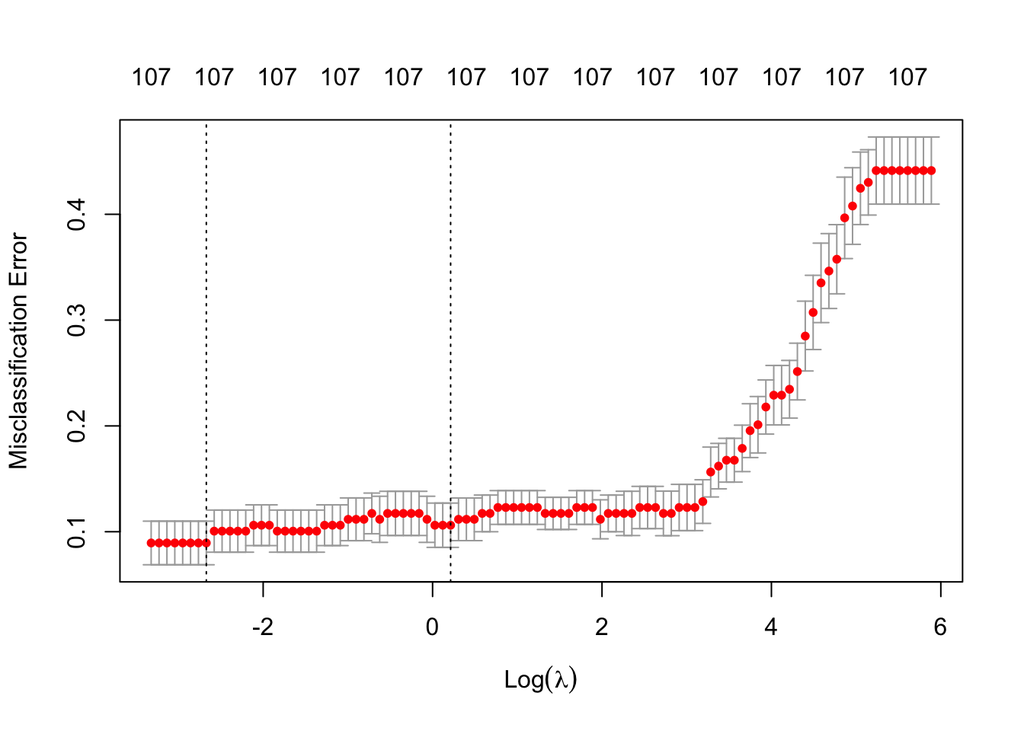

```r
plot(cvfit)
```

#### $\lambda_{min}$ value

We can get the value of $\lambda_{min}$ and the model coefficients:

```r
cvfit$lambda.min
```

```
## [1] 0.06918438
```

#### Coefficients at $\lambda_{min}$

```r
coef(cvfit, s = "lambda.min")
```

```
## 108 x 1 sparse Matrix of class "dgCMatrix"
##                        s1
## (Intercept) -29.071634993
## AGAP9        -0.016591014
## AIRE          0.371812738
## ANKRD22      -0.088451987
## APOL1         0.134411789
## APOL6        -0.194681608
## ATP1A1        0.241329131
## BATF2        -0.120270601
## BCL6          0.097798115
## BLK           0.120170715
## C16orf7      -0.189030143
## C1QB         -0.076962714
## C1QC          0.022499453
## C4ORF18      -0.482339626
## C5            0.046333546
## CCDC14       -0.013681996
## CCDC78       -0.205839700
## CCR6          0.214495578
## CD1C         -0.022227221
## CD79A        -0.002636596
## CD79B        -0.007089628
## CIRBP        -0.055432031
## CTSA         -0.780369926
## CXCR5         0.039546107
## CXorf40B      0.155024388
## CYP4F3       -0.474048146
## DARS2         0.199429466
## DERA          0.089091480
## DUSP3        -0.399476056
## ENO3          0.395342290
## ETV7         -0.037239658
## EXOC2         0.212604856
## FAM20A       -0.187845605
## FCER1G        0.186169960
## FCGR1A        0.021705810
## FCGR1B        0.020930976
## FLVCR2        0.027531550
## FUT4          0.141719024
```

[output cut: 55 more lines]

```
## UCP2         -0.036419759
## VAMP5        -0.032720316
## WARS          0.208502545
## ZNF202        0.139152522
## ZNF296        0.279697419
## ZNF419        0.167911163
## ZNRF1         0.208960226
## ACTB          0.159313869
## FCGR1C        0.014161085
## GAPDH        -0.368721112
## GUSB         -0.073562926
## HPRT1         0.104055750
## LOC728744    -0.398002254
## PGK1          0.256067804
## TBP           0.155737919
```

## Elastic Net Regression

Set family option to “binomial” in the glmnet function:

```r
fit <- glmnet(nano_data[,-1],nano_data$TBStatus, family = "binomial", alpha=0.5)
```

### Visualize L1

We can visualize the coefficients by executing the plot method:

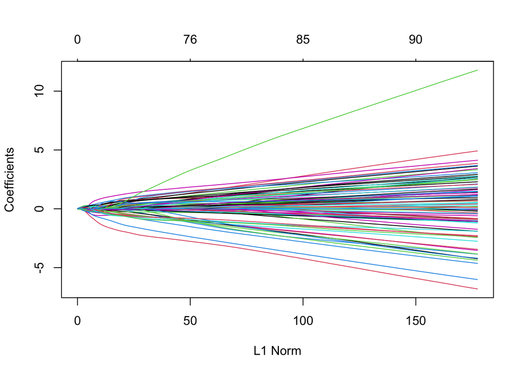

```r
plot(fit)
```

### Print summary

A summary of the glmnet path at each step is displayed if we just enter the object name or use the print function:

```r
print(fit)
```

```
##
## Call:  glmnet(x = nano_data[, -1], y = nano_data$TBStatus, family = "binomial",      alpha = 0.5)
##
##     Df  %Dev  Lambda
## 1    0  0.00 0.72150
## 2    9  4.77 0.65740
## 3   13 10.62 0.59900
## 4   16 15.99 0.54580
## 5   19 20.78 0.49730
## 6   21 25.06 0.45310
## 7   22 28.86 0.41280
## 8   24 32.26 0.37620
## 9   24 35.38 0.34270
## 10  26 38.19 0.31230
## 11  26 40.72 0.28460
```

[output cut: 89 more lines]

### Results $\lambda=0.7$

```r
coef(fit, s = .7)
```

```
## 108 x 1 sparse Matrix of class "dgCMatrix"
##                        s1
## (Intercept) -0.1514090973
## AGAP9        .
## AIRE         .
## ANKRD22      .
## APOL1        .
## APOL6        .
## ATP1A1       0.0045465029
## BATF2       -0.0004400007
## BCL6         .
## BLK          .
## C16orf7      .
## C1QB         .
## C1QC         .
## C4ORF18      .
## C5           .
## CCDC14       .
## CCDC78       .
## CCR6         0.0076230450
## CD1C         .
## CD79A        .
## CD79B        .
## CIRBP        .
## CTSA         .
## CXCR5        .
## CXorf40B     .
## CYP4F3       .
## DARS2        0.0004006315
## DERA         .
## DUSP3        .
## ENO3         .
## ETV7         .
## EXOC2        0.0047691070
## FAM20A       .
## FCER1G       .
## FCGR1A       .
## FCGR1B       .
## FLVCR2       .
## FUT4         .
```

[output cut: 55 more lines]

```
## UCP2         .
## VAMP5        .
## WARS         .
## ZNF202       .
## ZNF296       .
## ZNF419       .
## ZNRF1        .
## ACTB         .
## FCGR1C       .
## GAPDH        .
## GUSB         .
## HPRT1        .
## LOC728744    .
## PGK1         .
## TBP          .
```

### Results $\lambda = 0.6$:

```r
coef(fit, s = .6)
```

```
## 108 x 1 sparse Matrix of class "dgCMatrix"
##                        s1
## (Intercept) -2.4074197442
## AGAP9        .
## AIRE         .
## ANKRD22      .
## APOL1        .
## APOL6        .
## ATP1A1       0.0362973480
## BATF2       -0.0137183046
## BCL6         .
## BLK          .
## C16orf7      .
## C1QB         .
## C1QC         .
## C4ORF18      .
## C5           .
## CCDC14       .
## CCDC78       .
## CCR6         0.0409067979
## CD1C         .
## CD79A        .
## CD79B        .
## CIRBP        .
## CTSA         .
## CXCR5        .
## CXorf40B     .
## CYP4F3       .
## DARS2        0.0238620318
## DERA         .
## DUSP3        .
## ENO3         .
## ETV7         .
## EXOC2        0.0377532642
## FAM20A       .
## FCER1G       .
## FCGR1A       .
## FCGR1B       .
## FLVCR2       .
## FUT4         .
```

[output cut: 55 more lines]

```
## UCP2         .
## VAMP5        .
## WARS         .
## ZNF202       .
## ZNF296       .
## ZNF419       0.0051065396
## ZNRF1        .
## ACTB         .
## FCGR1C      -0.0009113511
## GAPDH        .
## GUSB         .
## HPRT1        .
## LOC728744    .
## PGK1         .
## TBP          0.0163877915
```

### Results $\lambda=0.55$

```r
coef(fit, s = 0.55)
```

```
## 108 x 1 sparse Matrix of class "dgCMatrix"
##                       s1
## (Intercept) -3.427487188
## AGAP9        .
## AIRE         .
## ANKRD22      .
## APOL1        .
## APOL6        .
## ATP1A1       0.051067678
## BATF2       -0.022818322
## BCL6         .
## BLK          .
## C16orf7      .
## C1QB         .
## C1QC         .
## C4ORF18      .
## C5           .
## CCDC14       .
## CCDC78       .
## CCR6         0.054301061
## CD1C         .
## CD79A        .
## CD79B        .
## CIRBP        .
## CTSA         .
## CXCR5        .
## CXorf40B     .
## CYP4F3       .
## DARS2        0.037557125
## DERA         .
## DUSP3        .
## ENO3         .
## ETV7         .
## EXOC2        0.055210634
## FAM20A      -0.005933189
## FCER1G       .
## FCGR1A       .
## FCGR1B      -0.003635409
## FLVCR2       .
## FUT4         .
```

[output cut: 55 more lines]

```
## UCP2         .
## VAMP5        .
## WARS         .
## ZNF202       .
## ZNF296       .
## ZNF419       0.018910068
## ZNRF1        .
## ACTB         .
## FCGR1C      -0.008041346
## GAPDH        .
## GUSB         .
## HPRT1        .
## LOC728744    .
## PGK1         .
## TBP          0.026232530
```

Model coefficients for $\lambda = 0.05$:

```r
coef(fit, s = 0.05)
```

```
## 108 x 1 sparse Matrix of class "dgCMatrix"
##                       s1
## (Intercept)  9.626527515
## AGAP9        .
## AIRE         0.233727100
## ANKRD22      .
## APOL1        .
## APOL6        .
## ATP1A1       0.291610759
## BATF2       -0.152173295
## BCL6         .
## BLK          0.002546957
## C16orf7      .
## C1QB        -0.058539246
## C1QC         .
## C4ORF18     -0.461887276
## C5           .
## CCDC14       .
## CCDC78       .
## CCR6         0.188808267
## CD1C         .
## CD79A        .
## CD79B        .
## CIRBP        .
## CTSA        -0.734020154
## CXCR5        .
## CXorf40B     .
## CYP4F3      -0.462560368
## DARS2        0.028394666
## DERA         .
## DUSP3       -0.223027472
## ENO3         .
## ETV7         .
## EXOC2        0.149711727
## FAM20A      -0.242800378
## FCER1G       .
## FCGR1A       .
## FCGR1B       .
## FLVCR2       .
## FUT4         .
```

[output cut: 55 more lines]

```
## UCP2         .
## VAMP5        .
## WARS         .
## ZNF202       .
## ZNF296       0.284444451
## ZNF419       0.013163775
## ZNRF1        .
## ACTB         .
## FCGR1C       .
## GAPDH        .
## GUSB         .
## HPRT1        .
## LOC728744    .
## PGK1         .
## TBP          .
```

### Cross-validation

The function **glmnet** returns a sequence of models for the users to choose from. **Cross-validation** is perhaps the simplest and most widely used method to select a model. **cv.glmnet** is the main function to do cross-validation here, along with various supporting methods such as plotting and prediction.

```r
set.seed(0)
cvfit <- cv.glmnet(as.matrix(nano_data[,-1]), nano_data$TBStatus, family = "binomial",
                   type.measure = "class",
                   alpha=0.5)
```

#### Cross-validation plot

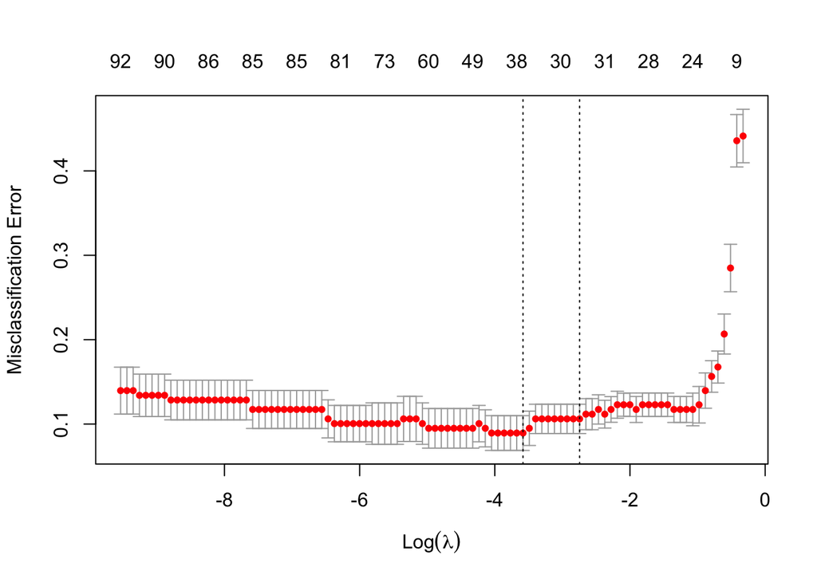

```r
plot(cvfit)
```

#### $\lambda_{min}$ value

We can get the value of $\lambda_{min}$ and the model coefficients:

```r
cvfit$lambda.min
```

```
## [1] 0.02780151
```

#### Coefficients at $\lambda_{min}$

```r
coef(cvfit, s = "lambda.min")
```

```
## 108 x 1 sparse Matrix of class "dgCMatrix"
##                       s1
## (Intercept) 15.027654432
## AGAP9        .
## AIRE         0.279224728
## ANKRD22      .
## APOL1        .
## APOL6       -0.015725367
## ATP1A1       0.260709443
## BATF2       -0.147913779
## BCL6         .
## BLK          .
## C16orf7      .
## C1QB        -0.094764495
## C1QC         .
## C4ORF18     -0.564320579
## C5           .
## CCDC14       .
## CCDC78       .
## CCR6         0.226706365
## CD1C         .
## CD79A        .
## CD79B        .
## CIRBP        .
## CTSA        -1.188511726
## CXCR5        .
## CXorf40B     .
## CYP4F3      -0.708609665
## DARS2        .
## DERA         .
## DUSP3       -0.218720095
## ENO3         0.060116879
## ETV7         .
## EXOC2        .
## FAM20A      -0.332227637
## FCER1G       0.119425017
## FCGR1A       .
## FCGR1B       .
## FLVCR2       .
## FUT4         .
```

[output cut: 55 more lines]

```
## UCP2         .
## VAMP5        .
## WARS         .
## ZNF202       .
## ZNF296       0.335978215
## ZNF419       .
## ZNRF1        .
## ACTB         0.268674623
## FCGR1C       .
## GAPDH        .
## GUSB         .
## HPRT1        .
## LOC728744   -0.147077379
## PGK1         .
## TBP          .
```